# Integrated species distribution models to account for sampling biases and improve range wide occurrence predictions: an example

2022-11-29

## Introduction

To support our manuscript, we wrote an example analysis for one of the study species, sword-billed hummingbird (Ensifera ensifera). Here we introduce the data sets of the species, and fit models PO, PA, PO+PA, PO+PA+samp., and PO+PA+restr. (see Table 1 in the manuscript for the definition of the models).

```r
suppressPackageStartupMessages({
  library(raster)
  library(ggplot2)
  library(pracma)
  library(caret)
  library(pROC)
  library(flexclust)
  library(irr)
  library(spdep)
  library(INLA)
  library(gridExtra)
  library(gtable)
  library(RColorBrewer)
  library(wesanderson)
  library(tidyverse)
  library(rgdal)
  library(R.utils)
  library(maptools)
})

.wd = getwd()

#---- Set parameters for model runs ----#
#model version
model_v = 1

#read in species list
species_list = read.csv('R/Species_list_cross_validation.csv', header = F)[[1]]

#option for spatially thin PO records
thinning = FALSE
thinning_PA = FALSE

#set the number of quadrature points in the coarse scale grid
target_n_obs = 20000

#size of predictive marginal distributions
n_samples = 500

#get offset values
get_offsets = FALSE

#whether weights are assigned according to the area related to a quadrature point
weights_area = TRUE

#create indices
thin_mark = ifelse(thinning, 'thin', 'not_thin')
thin_PA_mark =  ifelse(thinning_PA, '_thin_PA', '_not_thin_PA')
weights_mark = ifelse(weights_area, 'wa', 'not_wa')

#get sword-billed hummingbird
.species = species_list[10]
model_labels = c('PO', 'PA', 'Joint', 'PO', 'PA', 'PO+PA', 'PO+PA+samp.',
                  'PO + restr.', 'PA + restr.', 'PO+PA+restr.')

#set the color scale
col.brk=data.frame(cols=c(grey(seq(.8,.2,length=24)),colorRampPalette(c('steelblue4', 'steelblue1','gold','gold3', 'red1', 'red4'))(50)))
#make sure the top color is red
col.brk$cols[(nrow(col.brk)-1)]='#8B0000'
```

## Data

The presence-only and presence-absence data, quadrature points and weights associated with the presence-only points and the environmental covariates in the across the data points are already stored in RData files. They are called with the same functions, which can be used for creating the data lists. In Set_data_for_inference.R, we also create the mesh of triangulars (for INLA) and set the cross-validation folds.

```r
## Load data and model fits
source('R/Get_data.R')
data = Get_data(.wd, .species, thinning, target_n_obs, weights_area, get_offsets)
# Load data set specific to INLA run
source('R/Set_data_for_inference.R')
data_inla = Set_data_spde(.wd, .species, thinning, target_n_obs, weights_area, data)
```

Here we plot the data.

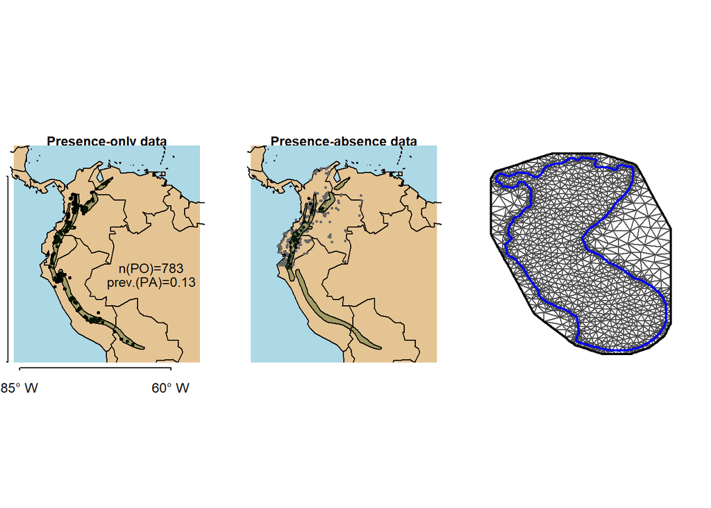

Spatial distribution of presence-only and presence-absence points and the constrained refined Delaunay triangulation (=mesh). In the plots for data points, species range from an expert range map is marked with grey. In presence-absende plot, black dots are for species presences and gray dots are for species absences.

## Model fitting

Next we fit models and plot their predicted log-intensities. The script defining the models and stacking data for INLA can be looked from the RunInference source codes:

```r
#estimate/load model
source('R/RunInference_inla_spat.R')
output_spat = RunInference(.wd, .species, data_inla, thinning, thinning_PA, weights_area, target_n_obs, model_v)

source('R/RunInference_inla_spat_samp.R')
output_spat_samp = RunInference(.wd, .species, data_inla, thinning, thinning_PA, weights_area, target_n_obs, model_v)

source('R/RunInference_inla_spat_rsr.R')
output_spat_rsr = RunInference(.wd, .species, data_inla, thinning, thinning_PA, weights_area, target_n_obs, model_v)
```

Species range-wide predictions.

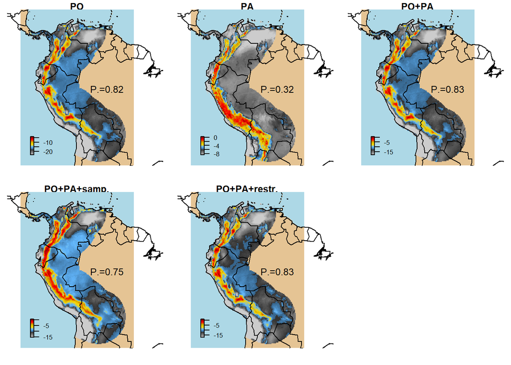

Predicted log-intensities across the study area. Proportion of the predicted intensities inside the expert range map are marked in the prediction plot.